# Fisher matrix for gravitational wave forecasting

[figure not shown]

> When we build Einstein Telescope, how many compact binary signals will it be able to detect? How well will it localize them in the sky? How well will it measure their parameters?

These are the questions that are being asked to us in order to do cost-benefit analyses, and in general to estimate the performance of any potential future detector, such as ET.

We will start by discussing the problem of *detecting* a gravitational signal, and then move to *analyzing* it.

## Gravitational wave detection

The gravitational-wave **detection** problem statement is as follows: we have data

$$d(t) = \underbrace{h_\theta(t)}_{\text{GW}} + \underbrace{
n _{\text{Gaussian}} (t) +
n _{\text{non-Gaussian}} (t)
}_{\text{noise}\ n(t)}$$

The fundamental strategy used in order to detect gravitational wave signal is called *matched filtering*. Consider a stream of data $d(t)$ consisting of a signal $h(t)$ plus additive Gaussian noise $n(t)$ described by a Power Spectral Density $S_n(f)$, such that $d(t) = n(t) + h(t)$.

We want to detect $h$ in a situation where the absolute value of $h(t)$ is much smaller than that of $n(t)$. A *linear filter* can be used to this end: we will extract some function of the data in the form

$$\hat{\rho}(\tau ) = \int d(t + \tau) f(t) \text{d}t$$

for some $f(t)$, such that this $\hat{\rho}$ peaks where the signal is, in as promiment a way as possible. Formally: we want the ratio

$$\frac{S}{N} = \frac{\hat{\rho} (\text{a signal is present})}{ \text{root-mean-square of } \hat{\rho}}$$

to be as large as possible. It turns out that the best way to accomplish this is through a filter that’s weighted with the noise spectrum.

Let us define $(\cdot | \cdot)$ as the noise-weighed inner product between waveforms,

$$(a | b) = 4 \Re \int_0^\infty \frac{a(f) b^*(f)}{S_n(f)}\text{d}f \,,$$

The optimal statistic $\hat{\rho}$ we want will then be (proportional to) $(d|h)$. Then, the signal-to-noise ratio will be:

### Signal-to-noise ratio

The signal-to-noise ratio (SNR) statistic $\rho$ for the data $d$, assuming a template $h$, is $\rho = (d | h) / \sqrt{(h|h)}$. This is the quantity that matched-filter signal searches attempt to maximize. In general this will be given by $\rho = [(n|h) + (h|h)] / \sqrt{(h|h)}$, but if we are performing a forecast we cannot know in advance what the noise realization will be. Fortunately, the expected contribution of the term $(n|h)$ is zero since $\langle n(t) \rangle = 0$, so the expectation value is just $\rho \approx \sqrt{(h|h)}$:

$$\rho _{\text{opt}} = \sqrt{(h|h)} = 2 \sqrt{\int_0^\infty \frac{|h(f)|^2}{S_n(f)} \text{d}f}
\,.$$

This does not mean that we are neglecting the noise, since its *distribution* $S_n$ is still taken into account: for example, consider the behaviour under a global rescaling of the noise PSD: $\rho \propto 1 / \sqrt{S_n}$. At each frequency $f$ the noise is normally distributed, with variance $S_n(f)$ and mean zero, so we are just considering the mean value of the noise distribution.

### SNR thresholds

If we were searching for a signal without any possible shift in time and with the certainty that the noise did not contain any glitches or non-Gaussianities, then the SNR would simply follow a $\chi^2$ distribution with two degrees of freedom (Babak et al. 2013), meaning that we could reach “five $\sigma$” significance ($p$-value of $5.7\times 10^{-7}$) with a threshold of $\rho = 5.5$.

This is not the case in real data, since both the aforementioned assumptions are false: the different possible arrival times of a signal are effectively “more trials”, but more importantly the non-Gaussianity of the noise means that high-SNR triggers in a matched filtering search will be much more common than simple Gaussian statistics would indicate. Accounting for these factors is tricky, and in real data it is typically accomplished by performing time-slides: taking real detector data, but shifted across detectors by more than $t_{\text{min}} = d/c$, where $d$ is the maximum distance separating them. In the assumption that signals are rare (which holds for current detectors, for ET this will have to be challenged), this allows us to generate arbitrary amounts of noise-only realistic data by removing all possible coincidences. We can then compute the rate of noise instances surpassing our threshold, even if this rate is very low. With this, we can compute the false-alarm rate (FAR) associated to a given SNR threshold. It should also be noted that real searches also include other vetoes, such as requiring that each frequency band contributes appropriately to the SNR (Nitz et al. 2018), which allows us to discard many loud glitches.

The scaling of the FAR as a function of SNR, in the absence of large outliers, is typically exponential (Lynch et al. 2018):
$$\text{FAR} = \text{FAR}_8 \exp \left( - \frac{\rho - 8}{\alpha}\right) \,.$$

The specific values for the FAR at $\rho = 8$ and the scaling parameter $\alpha$ are found through a fit, and they depend on the signal template. A fit of O1 data found $\alpha = 0.18$ and $\text{FAR}_8 = 5500 \text{yr}^{-1}$ for BBH, and $\alpha = 0.13$ and $\text{FAR}_8 = 30000 \text{yr}^{-1}$ for BNS. This value of $\alpha$ means that the exponential cutoff is quite steep: for example, bringing the BNS FAR from 30 thousand per year to just one per year only requires us to raise the threshold to $\rho = 9.4$.

### Forecasting SNR

For the purposes of forecasting, then, what SNR threshold should we consider as the minimum for detectability? We cannot know yet which glitches will affect our future detector, but we can safely say that a threshold in the range of 8 to 12 is probably acceptable - the changes in detection horizon associated with different thresholds in this range are comparatively small, while the false alarm rate decreases exponentially.

The SNR is easy to estimate and not too dependent on the specifics of the waveform model: for one, it discards all phase information, since the waveform appears in it as $|h(f)|^2$.

and also waveform models for compact binaries differ significantly only in the high-frequency region; for most of the inspiral the signal is decently modelled by a simple powerlaw $h\propto f^{-7/6}$, therefore the overall SNR integral is much more stable under changes of model than the parameter estimation forecasts we will discuss later.

## Gravitational wave data analysis

When we measure gravitational wave data $d(t)$, we will have a contribution from noise $n(t)$ and signal $h_\theta(t)$, where $\theta$ are the parameters: $d = n + h_\theta$. We can estimate the parameters $\theta$ by exploring the posterior distribution

$$p(\theta | d) = \mathcal{L}(d | \theta ) \pi (\theta ) = \mathcal{N} \exp \left( (d | h_\theta) - \frac{1}{2} (h_\theta | h_\theta) \right) \pi (\theta )\,,$$

while $\pi (\theta )$ is our prior distribution on the parameters. This kind of analysis is assuming that the noise is Gaussian, and described by the power spectral density (PSD) $S_n(f)$.

This posterior, in full generality, is an arbitrary function of more than a dozen parameters, making it somewhat difficult to calculate and interpret. Typically, the algorithms used to compute it for real signals explore the parameter space in some stochastic manner, and yield a set of some thousands of samples $\lbrace\theta\rbrace_i$.

This makes it simple to compute summary statistics like the average of a parameter $\langle \theta_i \rangle$, the variance $\sigma_i^2 = \langle (\theta_i- \langle \theta_i\rangle)^2 \rangle$, as well as covariances $\mathcal{C}_{ij} =\langle (\theta_i- \langle \theta_i\rangle) (\theta_j- \langle \theta_j\rangle) \rangle = \langle \Delta \theta ^i \Delta \theta ^j\rangle$.

### Correlations

Here is a graphical representation of correlation: the distribution for a multivariate normal with correlation matrix

$$\mathcal{C} = \left[\begin{array}{cc}
1 & 0.8 \\
0.8 & 1
\end{array}\right]$$

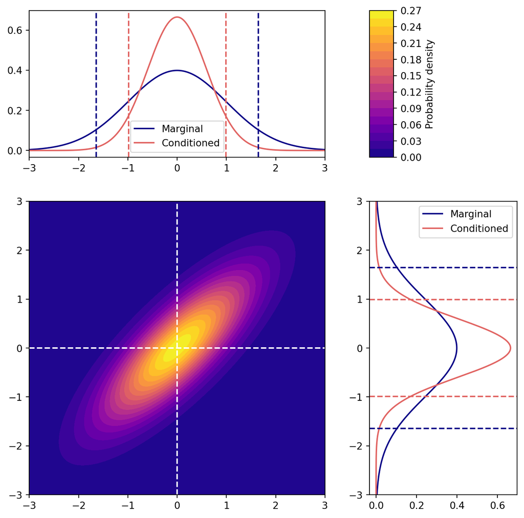

```python
from multivariate_normal import MultivariateNormal
n = MultivariateNormal([0, 0], [[1, 0.8], [0.8, 1]])
n.plot_2d_analytical(0, 0, .9)
```

At this stage, we are not making any approximation, and the covariance matrix is just a summary tool.

These quantities give us an estimate of how well any given parameter is constrained, although they do not tell the whole story especially in the regime where the error $\sigma$ starts to be comparable with the signal. For those cases, in general, if the posterior is available the best idea is to plot it; this is typically done as a corner plot, which shows the correlations among different parameters. Here is an example showing the correlation between distance and inclination angle for GW170817.

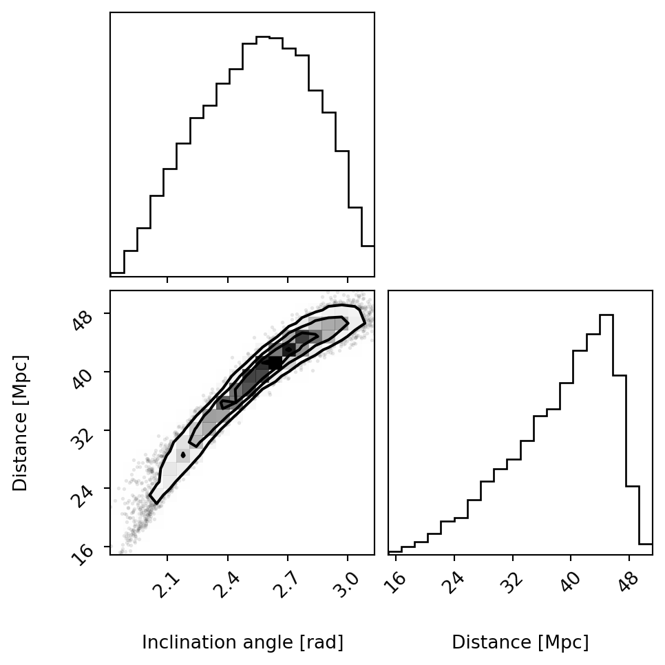

```python
import numpy as np
import matplotlib.pyplot as plt
import corner
import h5py

# load GWTC-1 posterior for GW170817
# from here: https://gwosc.org/eventapi/html/GWTC-1-confident/GW170817/v3/
f = h5py.File('../data/GW170817_GWTC-1.hdf5', 'r')
dataset = f['IMRPhenomPv2NRT_lowSpin_posterior']
cosi = dataset['costheta_jn']
dist = dataset['luminosity_distance_Mpc']

corner.corner(np.vstack((np.arccos(cosi), dist)).T, labels=['Inclination angle [rad]', 'Distance [Mpc]'])
plt.show()
```

## Parameter dependence of CBC signals

The signal $h_\theta(t)$ (or in the Fourier domain, $h_\theta (f)$) depends on several parameters, both intrinsic (describing the source itself) and extrinsic (describing the geometrical relation between detector and source). Here I will describe these parameters and also give an example of the error with which they are measured in the case of GW170817. For most of them I will quote the figure $\sigma _x / x$, meaning the standard deviation of the posterior samples normalized to the value of the parameter $x$.

For the purposes of this section, I will not show Fisher matrix results but actual variances, covariances et cetera computed from the samples of a full parameter estimation of GW170817.

### Intrinsic parameters

We can measure the component **masses** $m_1$ and $m_2$ with reasonable accuracy ($\sigma _x / x \sim 10\%$), but their combination called *chirp mass* $\mathcal{M}$ and defined as follows:

$$\mathcal{M} = \frac{(m_1 m_2 )^{3/5}}{(m_1 + m_2)^{1/5}}$$

is measured to much higher accuracy ($\sigma _x / x \sim 0.1\%$). This is because it affects the overall phasing of the signal, meaning that small changes in it will bring the signal-to-noise ratio very quickly.

On the other hand, the ratio between the masses, $q = m_1 / m_2$, is measured to worse accuracy than the masses themselves ($\sigma _x / x \sim 20\%$). An alternative parametrization for the mass ratio is the *symmetric* mass ratio, $\nu = \mu / M = q / (1+q)^2$ where $\mu = m_1 m_2 / M$ is the reduced mass while $M = m_1 + m_2$ is the total mass. These are measured with relative errors $\sigma _M / M \sim 3\%$ and $\sigma _\nu / \nu \sim 4\%$ respectively.

The chirp mass we are measuring with such precision is the so-called *detector-frame* mass, which for a source at **redshift** $z$ corresponds to
$$\mathcal{M} = \mathcal{M}_{\text{source}} ( 1 + z )$$

The signal only depends on this combination, and there is no way from the gravitational signal itself to disentangle source-frame mass from redshift.

Higher-order source properties are more difficult to measure: for typical analyses of GW170817, spin and tidal effects were included.

As for spin, the components of the **spin** of each star aligned to the orbital angular momentum, $\chi _{1z}$ and $\chi _{2z}$ were definitely not well-measured, with $\sigma _x / x \sim 3$ and 10 respectively.

In comparison, the effective spin parameter $\chi _{\text{eff}} = (m_1 \chi _{1z} + m_2 \chi _{2z} )/(m_1 + m_2)$ was better constrained, with $\sigma _x / x \sim 1$ (although quoting this figure is not that meaningful here, since it was found to be compatible with zero (Collaboration et al. 2019)).

The precessing spin $\xi _p$ was also not well-constrained.

Similarly, the **tidal parameters** $\Lambda _1$ and $\Lambda _2$, were not as well-constrained ($\sigma _x / x \sim 1.5$) as the effective tidal parameter $\widetilde{\Lambda}$ ($\sigma_x / x \sim 0.6$).

The tidal polarizability is defined as (Damour, Nagar, and Villain 2012):

$$\Lambda_i = \frac{2}{3} \kappa_2 \left( \frac{R_i c^2}{G m_i}\right)^5$$

and it measures to which extent the deformation of a compact star enhances the gravitational potential.

The reduced tidal parameter, on the other hand, is defined as

$$\widetilde{\Lambda} = \frac{16}{13} \frac{(m_1 + 12 m_2 ) m_1^4 \Lambda_1 + (m_2 + 12 m_1 ) m_2^4 \Lambda_2 }{(m_1 + m_2 ^5)}$$

### Extrinsic parameters

The signal’s overall amplitude depends on the source (luminosity) **distance** $d_L$ as $h \propto 1 / d_L$, and because of this we are able to measure it with some accuracy ($\sigma _x / x \sim 20\%$).

This parameter is, however, degenerate with the **inclination** of the source, $\iota$ — this is the angle between the orbital angular momentum of the binary and the vector connecting detector and source. A source for which $\iota$ is close to zero or to $\pi$ is said to be *face-on*, while a source for which $\iota$ is close to $\pi/2$ is said to be *edge-on*.

This parameter degenerates with the distance since both affect the amplitude; for the latter, the two polarizations for the highest-order spherical harmonic of gravitational wave emission scale like $h_+ \propto (1 + \cos^2 \iota)$ and $h_\times \propto \cos \iota$.

If we account for more harmonics (or, as they are more commonly referred to, **higher order modes**) the signal’s dependence on the inclination angle $\iota$ becomes more complex, and this may help in breaking the degeneracy.

In full generality, the waveform is given by

$$h(t) = \sum_{\ell \geq 2} \sum _{|m| \leq \ell} h_{\ell m}(t) ^{(-2)}Y_{\ell m} (\iota, \phi)$$

where the functions $^{(-2)}Y_{\ell m} (\iota, \phi)$ are called the *spin-weighted spherical harmonics* (Ajith et al. 2011). The $\ell = 2$, $m = \pm 2$ contribution is the aforementioned dominant one.

The remaining extrinsic parameters are the **arrival time** at geocenter $t_\oplus$, the overall free **phase** $\phi$, the **polarization** angle $\psi$, and finally the **sky position** $(\text{ra}, \text{dec})$.

```python
import numpy as np

def ninety_percent_region(sigma_ra, sigma_dec, cov_ra_dec, dec):

    delta_omega = np.abs(np.cos(dec)) * np.sqrt(
        sigma_ra**2 * sigma_dec**2
        - cov_ra_dec**2
    )
    return - delta_omega * 2 * np.pi * (180/np.pi)**2 * np.log(1 - .9)

sigma_ra = 0.0279
sigma_dec = 0.0377
cov_ra_dec = -0.00084
dec = -0.354
ra = 3.419


print(
    f'The 90% localization area for GW170817, in the Gaussian approximation, \n'
    f'is {ninety_percent_region(sigma_ra, sigma_dec, cov_ra_dec, dec):.0f} square degrees')
```

```
The 90% localization area for GW170817, in the Gaussian approximation,
is 28 square degrees
```

**GW150914 comparison**

The errors given before were for the neutron star binary GW170817, but things change somewhat in the case of a black hole binary. Here I show the case of GW150914. One can see that here, due to the much smaller number of cycles in band, the chirp mass is not better-measured than the total mass. Also, given the large sky area and the fact that this was a two-detector event, the Gaussian approximation fails in computing the sky area.

```python
import h5py
import numpy as np

def print_posterior_statistics(data_dict):
    data_dict['mchirp'] = (
        data_dict['mass1_det'] * data_dict['mass2_det']
        )**(3/5) / (data_dict['mass1_det'] + data_dict['mass2_det'])**(1/5)

    data_dict['mtot'] = (
        data_dict['mass1_det'] + data_dict['mass2_det']
        )

    units_errors = {
        'time': 's',
        'right_ascension': 'rad',
        'declination': 'rad',
        'theta_jn': 'rad',
    }

    for key in data_dict:
        data = data_dict[key]
        if key in units_errors:
            print(
                f'sigma_{key}: '
                f'{np.std(data):.3f} {units_errors[key]}'
            )
        else:
            print(
                f'sigma_{key} / {key}: '
                f'{np.std(data) / np.median(data):.3f}'
            )

    region = ninety_percent_region(
            np.std(data_dict["right_ascension"]),
            np.std(data_dict["declination"]),
            np.cov(
                data_dict["right_ascension"],
                data_dict["declination"],
            )[0, 1],
            np.median(data_dict["declination"]))

    print(
        f'The 90% localization area for GW150914, in the Gaussian approximation, \n'
        f'is {region:.0f} square degrees, \n'
        'while the true one was approximately 600 square degrees'
    )

try:
    f = h5py.File('../data/GW150914_data.h5')
    dataset = f['overall_post']
    data_dict = {}
    for key in dataset.dtype.fields.keys():
        data_dict[key] = dataset[key]
    print_posterior_statistics(data_dict)
except FileNotFoundError:
    print('GW150914 posterior not available - download it from https://dcc.ligo.org/LIGO-T1800235/public')
    print('and save it to the data/ folder as "GW150914_data.h5"')
```

```
sigma_a1 / a1: 0.707
sigma_a2 / a2: 0.608
sigma_distance / distance: 0.235
sigma_theta_jn: 0.507 rad
sigma_time: 0.003 s
sigma_mass1_det / mass1_det: 0.075
sigma_right_ascension: 0.560 rad
sigma_mass2_det / mass2_det: 0.087
sigma_declination: 0.197 rad
sigma_mchirp / mchirp: 0.035
sigma_mtot / mtot: 0.033
The 90% localization area for GW150914, in the Gaussian approximation,
is 1800 square degrees,
while the true one was approximately 600 square degrees
```

### Correlation structure

For each pair of parameters $\theta_i$, $\theta_j$ we select after running a parameter estimation job, we will be able to compute their Pearson correlation coefficient, which is their correlation normalized to their standard deviations:
$$\rho_{ij} = \frac{\operatorname{cov}(\theta _i, \theta_j)}{\sigma_i \sigma_j}$$

This number will always lie between -1 and 1, with values near these extremes representing near-perfect (anti)correlation, while values near 0 represent uncorrelated variables. This only captures *linear* correlations, so it does not tell the whole story, but it is still quite useful in understanding which parameters are generally to be understood as correlated or not.

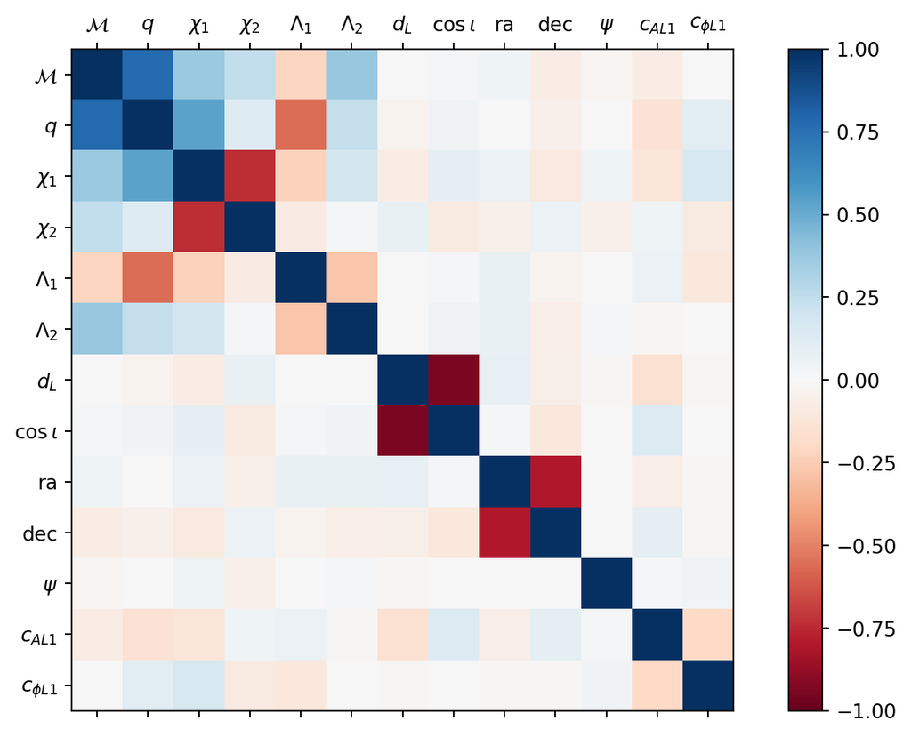

Figure 1: Correlations between some measured parameters for GW170817. $c_{AL1}$ and $c_{\phi L1}$ are two calibration parameters for the Livingston detector, included for reference, out of the $\sim$ 12 calibration parameters per detector used in real analyses. Arrival time and overall phase are not included since they were analytically marginalized in this particular analysis.

```python
# we start from the covariance matrix for an analysis of GW170817
# this is included in the auxiliary data for convenience

import numpy as np
import matplotlib.pyplot as plt
from matplotlib.colors import Normalize
from matplotlib.cm import ScalarMappable
from matplotlib import ticker

def plot_correlations(cov, symbols):
    n = len(symbols)

    sigmas = np.sqrt(np.diagonal(cov))
    correlations = cov / np.kron(sigmas, sigmas).reshape(n, n)

    cmap = plt.get_cmap('RdBu')
    normalization = Normalize(-1, 1)
    fig, axes = plt.subplots(figsize=(10, 6))
    axes.matshow(correlations, cmap=cmap, norm=normalization)
    for axis in [axes.xaxis, axes.yaxis]:
        axis.set_major_locator(ticker.FixedLocator(np.arange(n)))
        axis.set_major_formatter(ticker.FixedFormatter(symbols))
    plt.colorbar(ScalarMappable(cmap=cmap, norm=normalization), ax=axes)
    plt.show()

symbols = [
    '$\\mathcal{M}$',
    '$q$',
    '$\\chi_1$',
    '$\\chi_2$',
    '$\\Lambda_1$',
    '$\\Lambda_2$',
    '$d_L$',
    '$\\cos \\iota$',
    'ra',
    'dec',
    '$\psi$',
    '$c_{AL1}$',
    '$c_{\phi L1}$',
]
cov = np.loadtxt('../data/covariance_170817.txt')
plot_correlations(cov, symbols)
```

In Figure 1 we see the structure of the correlation matrix for an actual analysis of GW170817 (specifically, the one from Tissino et al. (2022)).

Note the important qualitative feature that the extrinsic parameters are overall uncorrelated from the intrinsic ones. This is qualitatively due to the fact that the extrinsic parameters are generally measured by *inter-detector* amplitude and time of arrival *differences*, while intrinsic parameters are generally measured by *averages* of amplitude and phase (Singer and Price 2016).

### Antenna pattern

The strain at the detector, $h(t)$, depends on the gravitational-wave strain $h_{ij}(t)$ through contraction with a **detection tensor** $D_{ij}$, which depends on the orientation and shape of the detector’s arms:
$$h(t) = h_{ij} (t) D_{ij}(t) = h_+ (t) F_+ (t) + h_\times (t) F_\times (t) \,.$$

For current detectors the time dependence of $D_{ij}$ is negligible, since the signal is in band for minutes at most, while for ET this will have to be taken into account. The Fisher matrix is typically computed in the frequency domain, which makes the computation trickier, but still feasible (see section 3.2 of Iacovelli et al. (2022) for more details).

In the following plot, we show the root-mean-square antenna pattern for several detectors: the current LVK network and ET. The ET pattern does not reach the highest values due to the angle between its arms: the optimal value of $\sqrt{F_+^2 + F_\times^2} = 1$ can only be achieved with orthogonal ones.

```python
from antenna_patterns import plot_antenna_pattern
```

**Virgo**

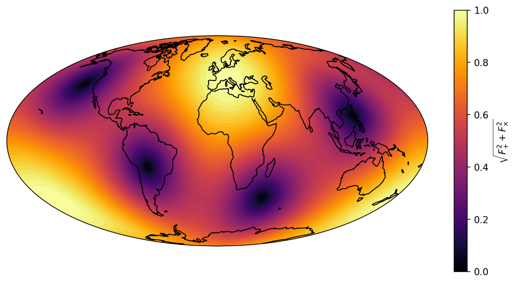

A plot of $\sqrt{F_+^2 + F_\times^2}$ for the Virgo detector.

```python
plot_antenna_pattern('V1')
```

**Hanford**

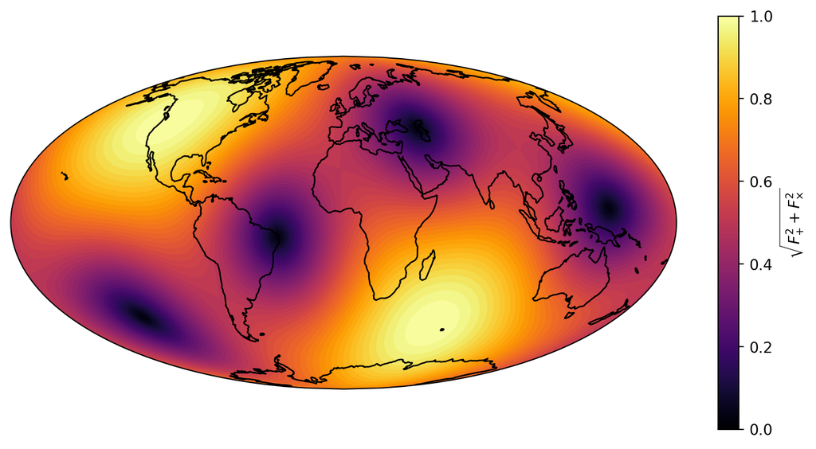

A plot of $\sqrt{F_+^2 + F_\times^2}$ for the LIGO Hanford detector.

```python
plot_antenna_pattern('H1')
```

**Livingston**

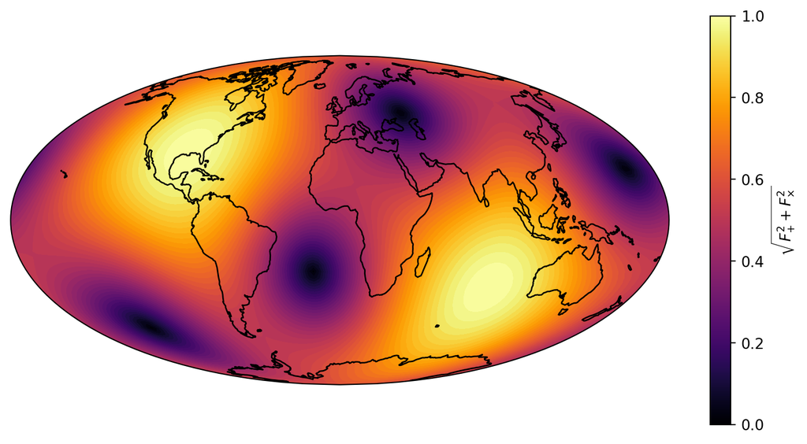

A plot of $\sqrt{F_+^2 + F_\times^2}$ for the LIGO Livingston detector.

```python
plot_antenna_pattern('L1')
```

**Kagra**

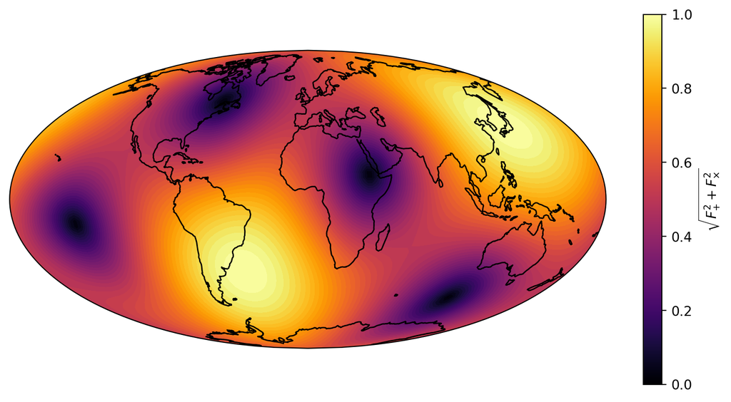

A plot of $\sqrt{F_+^2 + F_\times^2}$ for the Kagra detector.

```python
plot_antenna_pattern('K1')
```

**ET-1**

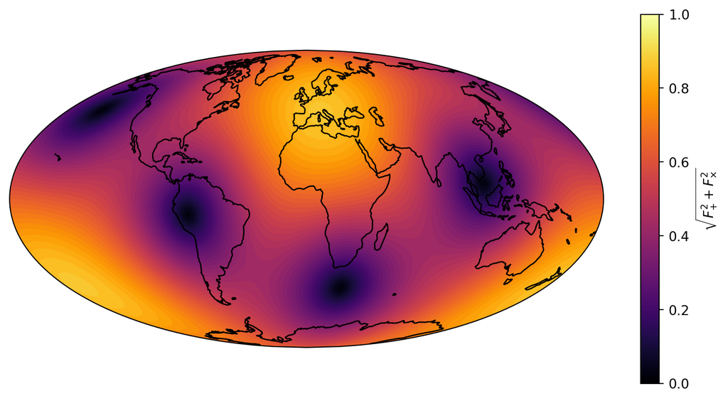

A plot of $\sqrt{F_+^2 + F_\times^2}$ for the ET-1 detector.

```python
plot_antenna_pattern('E1')
```

**ET-2**

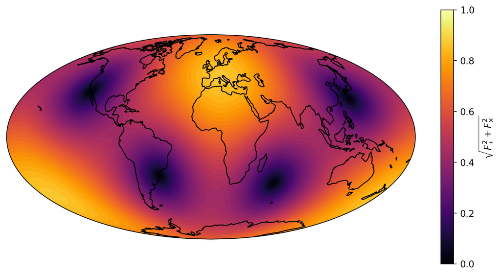

A plot of $\sqrt{F_+^2 + F_\times^2}$ for the ET-2 detector.

```python
plot_antenna_pattern('E2')
```

**ET-3**

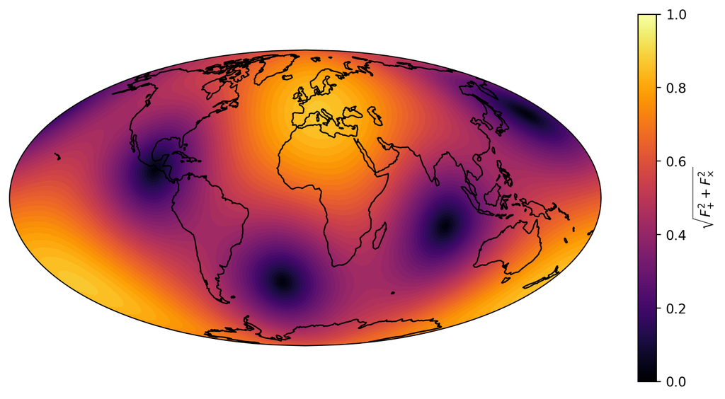

A plot of $\sqrt{F_+^2 + F_\times^2}$ for the ET-3 detector.

```python
plot_antenna_pattern('E3')
```

## Fisher matrix

In the Fisher matrix approximation, we are considering the gravitational wave likelihood as if it was written like

$$\mathcal{L}(d | \theta) \approx \mathcal{N} \exp \left(- \frac{1}{2} \Delta \theta^i \mathcal{F}_{ij} \Delta \theta^j \right)$$

for some normalization $\mathcal{N}$, where $\Delta \theta^i = \theta ^i - \langle \theta ^i \rangle$ denotes the deviation of the parameters from their mean values and where we are using the Einstein summation convention.

This is the expression of a multivariate normal distribution, with covariance matrix $\mathcal{C}_{ij} = \mathcal{F}_{ij}^{-1}$.

The Fisher matrix $\mathcal{F}_{ij}$ can be computed as the scalar product of the derivatives of waveforms:
$$\mathcal{F}_{ij} = \left.\left\langle \partial_i \partial_j \mathcal{L} \right\rangle \right|_{\theta = \langle \theta \rangle} = ( \partial_i h | \partial_j h ) = \Re \int_0^{\infty} \frac{1}{S_n(f)} \frac{\partial h}{\partial \theta _i} \frac{\partial h^*}{\partial \theta _j}\text{d}f\,.$$

These derivatives may be computed numerically or analytically (Dupletsa et al. (2023), Iacovelli et al. (2022)). Crucially, the computation is quite fast, typically taking on the order of seconds.

In the case of multiple detectors, we can compute the *network* Fisher matrix by adding the single-detector ones:

$$\mathcal{F}_{ij} = \sum_{k = 1}^N \mathcal{F}_{ij}^{(k)}$$

### Derivation

For a more in-depth derivation refer to Finn (1992); here we just give a simple argument. We can rewrite the derivatives of the log-likelihood as follows:

$$\begin{aligned}
\partial_i \partial_j \log \mathcal{L} &= \frac{1}{2} \partial_i \partial_j (d-h|d-h) \\
&= \frac{1}{2} \partial_i \partial_j \left((d|d) - 2 (d|h) + (h|h)\right) \\
&= \partial_i \left(- (d|\partial_j h) + (\partial_j h|h)\right) \\
&= \left(- (d|\partial_i \partial_j h) + (\partial_i \partial_j h|h) + (\partial_i h | \partial_j h)\right) \\
&= -(n|\partial_i \partial_j h) + (\partial_i h | \partial_j h)
\end{aligned}$$

and then, across all noise realizations, the term $(n|\partial_i \partial_j h)$ is equal to zero on average.

### Conditioning vs marginalizing

It is important to include all parameters when performing a Fisher matrix analysis. This is because not including a parameter which correlates to the one we care about in the Fisher analysis is equivalent to **conditioning** upon it having that specific value, while the correct operation to be performed is **marginalizing** over all possible values. These are different, as the figure in the Correlations section shows.

When dealing with the *correlation matrix* marginalizing simply amounts to ignoring some parameters, but crucially in the *Fisher matrix* this is not the case, since the inversion introduces mixing between the parameters.

## References

Ajith, P., M. Boyle, D. A. Brown, S. Fairhurst, M. Hannam, I. Hinder, S. Husa, et al. 2011. “Data Formats for Numerical Relativity Waves.” http://arxiv.org/abs/0709.0093.

Babak, S., R. Biswas, P. R. Brady, D. A. Brown, K. Cannon, C. D. Capano, J. H. Clayton, et al. 2013. “Searching for Gravitational Waves from Binary Coalescence.” *Physical Review D* 87 (2): 024033. https://doi.org/10.1103/PhysRevD.87.024033.

Collaboration, The LIGO Scientific, the Virgo Collaboration, B. P. Abbott, R. Abbott, T. D. Abbott, F. Acernese, K. Ackley, et al. 2019. “Properties of the Binary Neutron Star Merger GW170817.” *Physical Review X* 9 (1): 011001. https://doi.org/10.1103/PhysRevX.9.011001.

Damour, Thibault, Alessandro Nagar, and Loic Villain. 2012. “Measurability of the Tidal Polarizability of Neutron Stars in Late-Inspiral Gravitational-Wave Signals.” *Physical Review D* 85 (12): 123007. https://doi.org/10.1103/PhysRevD.85.123007.

Dupletsa, U., J. Harms, B. Banerjee, M. Branchesi, B. Goncharov, A. Maselli, A. C. S. Oliveira, S. Ronchini, and J. Tissino. 2023. “Gwfish: A Simulation Software to Evaluate Parameter-Estimation Capabilities of Gravitational-Wave Detector Networks.” *Astronomy and Computing* 42 (January): 100671. https://doi.org/10.1016/j.ascom.2022.100671.

Finn, Lee Samuel. 1992. “Detection, Measurement and Gravitational Radiation.” *Physical Review D* 46 (12): 5236–49. https://doi.org/10.1103/PhysRevD.46.5236.

Iacovelli, Francesco, Michele Mancarella, Stefano Foffa, and Michele Maggiore. 2022. “Forecasting the Detection Capabilities of Third-Generation Gravitational-Wave Detectors Using $\Texttt{}GWFAST{}$.” September 27, 2022. https://doi.org/10.48550/arXiv.2207.02771.

Lynch, Ryan, Michael Coughlin, Salvatore Vitale, Christopher W. Stubbs, and Erik Katsavounidis. 2018. “Observational Implications of Lowering the LIGO-Virgo Alert Threshold.” *The Astrophysical Journal* 861 (2): L24. https://doi.org/10.3847/2041-8213/aacf9f.

Nitz, Alexander H., Tito Dal Canton, Derek Davis, and Steven Reyes. 2018. “Rapid Detection of Gravitational Waves from Compact Binary Mergers with PyCBC Live.” *Physical Review D* 98 (July): 024050. https://doi.org/10.1103/PhysRevD.98.024050.

Singer, Leo P., and Larry R. Price. 2016. “Rapid Bayesian Position Reconstruction for Gravitational-Wave Transients.” *Physical Review D* 93 (2): 024013. https://doi.org/10.1103/PhysRevD.93.024013.

Tissino, Jacopo, Gregorio Carullo, Matteo Breschi, Rossella Gamba, Stefano Schmidt, and Sebastiano Bernuzzi. 2022. “Combining Effective-One-Body Accuracy and Reduced-Order-Quadrature Speed for Binary Neutron Star Merger Parameter Estimation with Machine Learning.” October 27, 2022. https://doi.org/10.48550/arXiv.2210.15684.